# Group Project 3

Biology 368/664 Bucknell University

Prof. Ken Field

9 Feb 2022

Dataset we are using: https://data.cdc.gov/NCHS/Provisional-COVID-19-Deaths-by-Sex-and-Age/9bhg-hcku/data

#INTRODUCTION TO EPIDEMIOLOGY:

Epidemiology is the “study of distribution and determinants of health related states among specified populations and the application of that study to control health problems” (A Dictionary of Epidemiology). The purpose of epidemiology in public health practice is to: (1) discover and analyze agents that affect heath, (2) determine causes of illness, disability, and death, (3) identify populations at risk, and (4) develop effective programs and services to to improve population health. Many epidemiologists solve health problems through a formal scientific approach that includes data collection, assessment, hypothesis testing, and action.

The employment of epidemiology has been notably publicized by the COVID-19 epidemic. As many people have been impacted by the virus in various capacities, this has sparked curiosity into how professionals identify, measure, and represent the epidemiology of such infections. In this R tutorial, we will assume the role of an epidemiologist and conduct a formal scientific method using a COVID-19 dataset provided by the Centers for Disease Control (CDC).

At the conclusion of this project, the following should be accomplished: 1. Relate epidemiology data collection to data science/analysis 2. Carry out the scientific method a. Perform an exploration of the dataset using R b. Perform basic data analysis using R c. Draw conclusions from the analysis

#INTRODUCTION TO R:

For many epidemiologists, the use of R Studio can be an effective program used to analyze collected data. As we are student epidemiologists, the aim of this tutorial and project is to introduce the application of data analysis in R. Using R studio, however, may be a daunting task for those with limited experience with computer coding. This basic introduction to R serves to help alleviate such stress. Throughout the project, we will slowly add to a toolbox of coding techniques.

First, it is important to understand the different types of files you can use in R Studio. Today, we will go over R Markdown and R Notebook.

R Markdown files allow you to include text with embedded R code chunks. When the document is knitted and finalized you will be able to see the text, code chunks, and the output of those embedded chunks. This is a great tool for authors because it saves the time of copying and pasting graphs or tables into a report and aids in reproducibility. Using R Markdown allows others to see exactly what was done to produce the figures.

R Notebook is quite similar to R Markdown except in a notebook only one line is sent at a time. In contrast, R Markdown executes the entire code chunk at once. Another large difference is when a R Notebook file is rendered no code is re-run, only the code that has already been run will be presented in produced document. Whereas when an R Markdown file is rendered all code chunks are re-run and it will not allow you to convert it to a document if there is an error in a code chunk.

##R Studio Basics:

Code chunks can be created in the RMD file. This is where desired functions of analysis can be performed. The creation of a code chuck can be completed via clicking the green square “C” in the above toolbar, or by using the keyboard shortcut of cmd+option+I on macOS.

Additionally, one can transform their markdown file into a HTML, PDF, or word document. This is referred to as “rendering” and can be done by clicking on the Knit button up in the R Studio toolbar. When you press Knit, it will run all of your code and create an output. If you want to omit the code but include the results of a chunk in your final document use echo = FALSE. If you want to omit the code and the results form the document use include = FALSE, as shown below.

To create headers in the text outside of the code chunk, once can place a single hash tag (#) in front of the text. For subheaders, use two hash tags (##). The following additions can be used to improve upon text: 1.To italicized text, surround the text with asterisk (*). 2.To bold text, surround it with two asterisks (**) 3.To create a list, place on asterisk (*) in front of each line.

These additions may appear throughout the following project, but would be more apparent if the RMD became knitted. The text will not appear italicized or bolded etc when you run your code, however, when the document has been finalized, the text will be altered accordingly.

Packages are collections of R functions, data, and compiled code which are stored in the library. The “System Library” can be found under the packages tab. The library will have checked boxes next to packages that are loaded into the current project. Packages can either be manually added (via installation tab in “Packages”) or coded in via a code chunk. For simplicity, all packages should be installed in the first code chunk, however, if a package is needed later in the project, it can always be added. A general list of packages one may want to always start off with include *dplyr*, *ggplot2*, *readr*, which is consistent of the tidyverse library (and should be added last in a code chuck).

Uses of the tidyverse library: 1.dplyr: Summarizes data quick and efficiently. 2.ggplot2: Data visualization 3.readr: Used read_csv()

Finally, the require function is used to ensure we actually get the package we want. If R Studio is unable to receive it, the code will come back with an error or FALSE.

Normally the R setup chunk can be included in the load libraries chunk, but they have been separated today to allow for proper explanation.

##Loading in Datasets:

Here we will walk through how to load your data set in, and what each part of the code means. First on the left you put the name you want for your data set. 1. < - This assigns the data frame to a variable 2. read_csv reads the data into RStudio as a data frame 3. Within the parentheses is how you tell it where to find your data 4. The period (.) indicates that the data is located one folder or click away from your RMD file

Click this green arrow to run a chunk of code that produces output. If this code is successful, you should see “Covid_19” appear as a dataframe in the top right box of the R Studio interface under the “Environment” tab.

```r
Covid_19 <- read_csv("./Data/Provisional_COVID-19_Deaths_by_Sex_and_Age.csv")
```

Click on the “Covid_19” dataset in the Environment tab and it will pull up a tab for you to view it. Before you start exploring your dataset, one should check to see if any column names have spaces in them. As R Studio has trouble reading spaces, it is easiest to rename these columns at the beginning of a project.

In the code chunk below, the spaces in the column names are changed in incorporate periods (.). This will make the data much easier to work with. After running the code chunk, check your dataframe to assure that the change was successful.

The structure of this function is as follows: names(dataframe)<-make.names(names(dataframe))

```r
names(Covid_19) <- make.names(names(Covid_19))
```

#EXPLORATION OF DATASET:

When a dataset is uploaded, there is an informal checklist to complete before visualization and analysis. One should become familiar with the elements in the dataset. The dataframe provides epidemiological data that is inclusive of: 1.Data “as of” date 2.Start dates of data collection 3.End dates of data collection 4.Grouped data by month, year, or total 5.Year of collected data (if applicable) 6.Month of data collection (if applicable) 7.State of data collection, or the entire United States 8.Sex divided into male, female, or total 9.Varied age groups or total collections 10.COVID-19 Deaths 11.Total Deaths 12.Pneumonia Deaths 13.Pneumonia Deaths and COVID-19 Deaths 14.Influenza Deaths 15.Pneumonia, Influenza, or COVID-19 Deaths 16.Footnotes

These variables are all divided into their own column. Just by initially looking through these variables, one can notice some complexities that should be noted. This dataframe includes both summed total data and individual unit data. Thus, both broad and narrow analysis can be made using the dataset. For example, could could compare total deaths in the United States by age group, or one could look at total deaths by month, sex, and age group in a particular state. Caution should be used, however, when filtering the data when conducting an analysis to answer a particular question. Finally, for this dataframe, there are 82620 observations that can be inferred as individual points of collection.

Key functions for visualizing data in R studio include: 1. &: Narrows search between dataframe and columns. 2. ~: Comparison of variables that are “dependent on” one another; defines relationship between independent and dependent variable.

##Formulating a Question:

Once the variables of the dataframe have been assessed, one should formulate a question. Assuming this dataframe was given to an epidemiologist, they may be particularity interested in the time, state, sex, and COVID-19 Death variables. Formulating a question at the beginning of data analysis can limit extraneous paths taken with a large dataset. A precise question and/or hypothesis can eliminate unnecessary variables from the subsequential analysis.

The questions we are interested in for this R tutorial: 1. Do males or females have more COVID-19 deaths per month? 2. Does west or east coast have more COVID-19 deaths? 3. Do older people have higher COVID-19 deaths?

The hypothesis(s) we are interested in for this R tutorial are: 1. We hypothesize that there will be no difference in COVID-19 deaths between the to genders. 2. We hypothesize that there will be more COVID-19 deaths reported for the East coast. 3. We hypothesize that there will be more COVID-19 deaths reported for older individuals

##Read Data:

The next step in exploratory data analysis is to read in a portion of data. The purpose of this task is to determine if the data is “messy” and should be “cleaned”. Messy data will often times not be orderly, have missing values, and is not suitable for immediate data visualization. As the data provided was from the CDC, we can expect relatively “clean” data.

```r
library(readr)
summary(Covid_19)
```

```
##   Data.As.Of         Start.Date          End.Date            Group
##  Length:82620       Length:82620       Length:82620       Length:82620
##  Class :character   Class :character   Class :character   Class :character
##  Mode  :character   Mode  :character   Mode  :character   Mode  :character
##
##
##
##
##       Year          Month           State               Sex
##  Min.   :2020   Min.   : 1.000   Length:82620       Length:82620
##  1st Qu.:2020   1st Qu.: 3.000   Class :character   Class :character
##  Median :2021   Median : 6.000   Mode  :character   Mode  :character
##  Mean   :2021   Mean   : 6.115
##  3rd Qu.:2021   3rd Qu.: 9.000
##  Max.   :2022   Max.   :12.000
##  NA's   :2754   NA's   :11016
##   Age.Group         COVID.19.Deaths     Total.Deaths     Pneumonia.Deaths
##  Length:82620       Min.   :     0.0   Min.   :      0   Min.   :     0.0
##  Class :character   1st Qu.:     0.0   1st Qu.:     39   1st Qu.:     0.0
##  Mode  :character   Median :    11.0   Median :    147   Median :    18.0
##                     Mean   :   391.7   Mean   :   2741   Mean   :   371.1
##                     3rd Qu.:    72.0   3rd Qu.:    660   3rd Qu.:    84.0
##                     Max.   :898699.0   Max.   :7070005   Max.   :798605.0
##                     NA's   :20551      NA's   :12132     NA's   :24504
##  Pneumonia.and.COVID.19.Deaths Influenza.Deaths
##  Min.   :     0.0              Min.   :    0.000
##  1st Qu.:     0.0              1st Qu.:    0.000
##  Median :     0.0              Median :    0.000
##  Mean   :   204.2              Mean   :    3.732
##  3rd Qu.:    36.0              3rd Qu.:    0.000
##  Max.   :466948.0              Max.   :10229.000
##  NA's   :20410                 NA's   :13510
##  Pneumonia..Influenza..or.COVID.19.Deaths   Footnote
##  Min.   :      0.0                        Length:82620
##  1st Qu.:      0.0                        Class :character
##  Median :     26.0                        Mode  :character
##  Mean   :    567.5
##  3rd Qu.:    125.0
##  Max.   :1239112.0
##  NA's   :23713
```

The readr package is used here because it can read and analyze large dataframes fast. Also note the library notation of readr. This operation loads/attaches packages and stores them in the “System Library” located under the Packages tab. This is an example of reading in a package into a code chuck, but again, this package was already loaded at the beginning of the project.

The summary of the “Covid_19” dataframe can be performed to get a general idea of what type of data is included (character, integer, and numeric variables) and it also preforms a basic analysis of the numeric data by providing quartile ranges.

At the beginning of this project, we removed the spaces in the column names. Should they be changed at any point, the rename function can be used. The general structure of the rename function is as follows: dataframe (can make new or use original)<-rename(dataframe, new column name=“column with spaces/Old name”)

Run the example below, and then check to see if the column name is changed in the “Covid_19” dataset. This example will be preformed using a column *not* of interest to our question(s)/hypothesis(s).

```r
Covid_19<- rename(Covid_19, Influenza = "Influenza.Deaths")
```

For practice, try renaming the “Pneumonia.Deaths” to “Pneumonia” using this structure outline.

```r
#Type Here
```

##Check Packaging:

Next, the packaging of the dataframe should be assessed. This validates that the dataframe is complete and is properly loaded. This can be complete using simple R commands. We can look at the number of columns and rows that the dataframe has.

```r
ncol(Covid_19)
```

```
## [1] 16
```

```r
nrow(Covid_19)
```

```
## [1] 82620
```

As the output of this code chuck matches the expected number of variables and observations (as displayed in the “Global Environment”), it can be assumed that the dataframe was uploaded correctly (although it can be checked by creating a table; a function performed later in this section).

##Run str()

Another general exploration tool that should be completed before analysis is running the structure of the dataframe. The output of this command replicates some knowledge we already have, however, it is another clean visual of the composition of the data and is an additional method to catch potential problems in the dataframe before analysis.

```r
str(Covid_19)
```

```
## spec_tbl_df [82,620 × 16] (S3: spec_tbl_df/tbl_df/tbl/data.frame)
##  $ Data.As.Of                              : chr [1:82620] "02/09/2022" "02/09/2022" "02/09/2022" "02/09/2022" ...
##  $ Start.Date                              : chr [1:82620] "01/01/2020" "01/01/2020" "01/01/2020" "01/01/2020" ...
##  $ End.Date                                : chr [1:82620] "02/05/2022" "02/05/2022" "02/05/2022" "02/05/2022" ...
##  $ Group                                   : chr [1:82620] "By Total" "By Total" "By Total" "By Total" ...
##  $ Year                                    : num [1:82620] NA NA NA NA NA NA NA NA NA NA ...
##  $ Month                                   : num [1:82620] NA NA NA NA NA NA NA NA NA NA ...
##  $ State                                   : chr [1:82620] "United States" "United States" "United States" "United States" ...
##  $ Sex                                     : chr [1:82620] "All Sexes" "All Sexes" "All Sexes" "All Sexes" ...
##  $ Age.Group                               : chr [1:82620] "All Ages" "Under 1 year" "0-17 years" "1-4 years" ...
##  $ COVID.19.Deaths                         : num [1:82620] 898699 203 795 93 244 ...
##  $ Total.Deaths                            : num [1:82620] 7070005 39473 70082 7377 11756 ...
##  $ Pneumonia.Deaths                        : num [1:82620] 798605 456 1345 271 390 ...
##  $ Pneumonia.and.COVID.19.Deaths           : num [1:82620] 466948 26 223 25 84 ...
##  $ Influenza                               : num [1:82620] 10229 24 193 65 81 ...
##  $ Pneumonia..Influenza..or.COVID.19.Deaths: num [1:82620] 1239112 657 2110 404 631 ...
##  $ Footnote                                : chr [1:82620] NA NA NA NA ...
##  - attr(*, "spec")=
##   .. cols(
##   ..   `Data As Of` = col_character(),
##   ..   `Start Date` = col_character(),
##   ..   `End Date` = col_character(),
##   ..   Group = col_character(),
##   ..   Year = col_double(),
##   ..   Month = col_double(),
##   ..   State = col_character(),
##   ..   Sex = col_character(),
##   ..   `Age Group` = col_character(),
##   ..   `COVID-19 Deaths` = col_number(),
##   ..   `Total Deaths` = col_number(),
##   ..   `Pneumonia Deaths` = col_number(),
##   ..   `Pneumonia and COVID-19 Deaths` = col_number(),
##   ..   `Influenza Deaths` = col_number(),
##   ..   `Pneumonia, Influenza, or COVID-19 Deaths` = col_number(),
##   ..   Footnote = col_character()
##   .. )
##  - attr(*, "problems")=<externalptr>
```

Immediately, one may notice the NA values listed for the year and month columns. These should be further evaluated. By rescrolling through the “Covid_19” dataframe, we can note that these NA values come from data that has been grouped. Grouped data, such as the Year and Month, make some values/anlaysis obsolete. “By total” data may be useful for future data as it is clean and easy to work with. Less filtering, as we will discuss later, may be required.

Beyond the NA values in the dataframe, there appears to be no other apparent issues. For future analysis using R beyond this project, however, NA values should always be evaluated as it could indicate missing variables or erroneous data that can not be used.

##Check Top and Bottom of Data:

Assessing the beginning and end of the dataframe is a useful tool to assure the data was loaded in property, the data is properly formatted, and that all expected data is present. Should dates be present in the dataframe, this technique is useful to check the ordering of them.

The “Covid_19” dataframe has dates and the ordering should be evaluated. This can be completed via the head and tail R commands. The structure of this commands is as follows: head/tail(dataframe[, c(column:column, #rows)]).

The brackets in this structure are a useful way to filter data via the use of a preloaded packaged (dplyr). An immediate comma is placed after the bracket to specify the filtering of data from a column. Typical use of brackets are structured as [row, column]. The c command allows for a string of commands. Finally, we can specify a range of columns of interest and the number of rows of data desired.

```r
head(Covid_19[, c(1:3, 10)])
```

```
## # A tibble: 6 × 4
##   Data.As.Of Start.Date End.Date   COVID.19.Deaths
##   <chr>      <chr>      <chr>                <dbl>
## 1 02/09/2022 01/01/2020 02/05/2022          898699
## 2 02/09/2022 01/01/2020 02/05/2022             203
## 3 02/09/2022 01/01/2020 02/05/2022             795
## 4 02/09/2022 01/01/2020 02/05/2022              93
## 5 02/09/2022 01/01/2020 02/05/2022             244
## 6 02/09/2022 01/01/2020 02/05/2022            2347
```

```r
tail(Covid_19[, c(1:3, 10)])
```

```
## # A tibble: 6 × 4
##   Data.As.Of Start.Date End.Date   COVID.19.Deaths
##   <chr>      <chr>      <chr>                <dbl>
## 1 02/09/2022 02/01/2022 02/05/2022               0
## 2 02/09/2022 02/01/2022 02/05/2022               0
## 3 02/09/2022 02/01/2022 02/05/2022               0
## 4 02/09/2022 02/01/2022 02/05/2022               0
## 5 02/09/2022 02/01/2022 02/05/2022               0
## 6 02/09/2022 02/01/2022 02/05/2022               0
```

Additionally, the tail command can be useful for identifying extraneous values or information placed at the end of the dataframe.

##Check Observations (N’s):

For data exploration, it is helpful to identify landmarks within a dataframe that can be used to check against the data being evaluated. This can be done a number of ways, but simply, a table can be made. For example, the “Covid_19” dataframe has distinguished variables that look at Sex and State observations. These variables can be crosschecked by the analysis to assure that the expected amount of observations are present.

The table function can be utilized in R. The structure of the command is as follows: table(dataframe$variable). The dollar sign can be used to narrow analysis by column within a dataframe.

```r
table(Covid_19$Sex)
```

```
##
## All Sexes    Female      Male
##     27540     27540     27540
```

```r
table(Covid_19$State)
```

```
##
##              Alabama               Alaska              Arizona
##                 1530                 1530                 1530
##             Arkansas           California             Colorado
##                 1530                 1530                 1530
##          Connecticut             Delaware District of Columbia
##                 1530                 1530                 1530
##              Florida              Georgia               Hawaii
##                 1530                 1530                 1530
##                Idaho             Illinois              Indiana
##                 1530                 1530                 1530
##                 Iowa               Kansas             Kentucky
##                 1530                 1530                 1530
##            Louisiana                Maine             Maryland
##                 1530                 1530                 1530
##        Massachusetts             Michigan            Minnesota
##                 1530                 1530                 1530
##          Mississippi             Missouri              Montana
##                 1530                 1530                 1530
##             Nebraska               Nevada        New Hampshire
##                 1530                 1530                 1530
##           New Jersey           New Mexico             New York
##                 1530                 1530                 1530
##        New York City       North Carolina         North Dakota
##                 1530                 1530                 1530
##                 Ohio             Oklahoma               Oregon
##                 1530                 1530                 1530
##         Pennsylvania          Puerto Rico         Rhode Island
##                 1530                 1530                 1530
##       South Carolina         South Dakota            Tennessee
##                 1530                 1530                 1530
##                Texas        United States                 Utah
##                 1530                 1530                 1530
##              Vermont             Virginia           Washington
##                 1530                 1530                 1530
##        West Virginia            Wisconsin              Wyoming
##                 1530                 1530                 1530
```

The net number of observations from each variable category (whether sex or state) should equals the amount of observations present in the dataframe, as there should be one entry for every observation. In this case, the numbers within each column matches the total number of observations, which is reassuring (27540 x 3 “sex categories = 82,620 observations, and 1,530 x 54”states” = 82,620 observations).

By looking at the states, however, we note that Puerto Rico, District of Columbia, New York City, and United States area all included on the dataset. While these locations have been included because they are US territory, locations of interest, or label data representative of the entire country instead of a state, this is important to take note of. It is up to the epidemiologist, in later sections, to determine whether these locations should be included in analysis depending on the question at hand, but this is a prime example of how exploring the dataset is an essential step when working with R Studio.

##Other Checks to Consider:

After an initial check over the dataframe has been complete, there are other factors to consider. For this purpose of this R tutorial, they will not be completed in full, but rather highlighted as things to be consider when conducting data analysis beyond this project. The first additional rule of thumb to consider is the validation of ones own data via a comparison with an external source. The CDC is very reliable, thus, the observations in this dataframe do not necessarily have be check. However, should further investigation be complete, eternal sources to consider include datasets from Johns Hopkins or Our World in Data. If one is using their own research data, they would certainly attempt an external validation of data. They would want to compare observations and numeric variables against another reliable source to conclude the absence of erroneous data.

An additional consideration is to try to answer ones question/hypothesis in the easiest way possible. Say your question simply asks which state had the most COVID-19 death in 2020. The data can simply be filtered out using a table. Certain questions like these do not need further exploration. The solution to these questions, however, should be challenged if possible. Factors such as some states not reporting data could be an issue (this is one such example, but this problem is not present in the “Covid_19” dataframe).

The purpose of this concluding paragraph on exploration of a dataset is to raise the point that not all questions require a deep dive into data analysis, rather, just a basic R exploration. Questions that compare variables, look at causality, and evaluate relationships, however, do require a lengthier analysis.

#VISUALIZATION OF DATASET AND VARIABLES OF INTEREST:

Before we begin visualization of our dataset, we should familiarize ourselves with some key ggplot functions. Below is a general template with explanations of functions that one can use when creating a plot.

Create a graph name and graph using the ggplot package a. Think of a title for the plot. Redefine dataframe via <-ggplot() b. The structure of a basic ggplot is as follows: (data.frame, aes(x=column, y= column)) -Unless specified, R will choose the best fit plot with the given data (it might not be the desired plot you want) -aes= axis. Define the x and y axis of your plot by the independent and dependent variable. c. Specify the plot you wish ggplot to create. Lets create a point plot with a line. The structure of this command is as follows: geom_() -Geom_point creates a line graph. You can leave it here or add a binary variable -Binary variables can be distinguished by the function colour =factor(BV). -All data points can be added via the jitter command. Add position= “jitter”. This is useful for visualize independent data points -The size and transparency of these data points can be defined using the commands alpha= and size= d. If desired, specify a line of best fit with standard deviation. Use command geom_smoooth. The structure of this command is as follows: geom_smooth(formula = y ~ x,method=‘lm’,aes(group = factor(BV), colour = factor(BV))) -The formula is specified as y~x as a linear line is desired -Method=’lm” to specify a linear model -Group and colour should equal factor of the binary variable e. Clean the graph up by changing: -Change legend position by using theme function of ggplot: theme(legend.position = “right, left, top, bottom”) -Change title of plot via function: ggtitle(“Title”) -Change name of x/y axis and legend title via function: labs(x= “X Title”, y= “Y Title”, color= “Legend Title”) OR you can individually state the x/y axis labels via xlab(“Title”) and ylab(“Title”) -Change aesthetics of x axis categories via function: theme(axis.text.x = element_text(angle = 1-180, vjust = numeric, hjust=numeric)) f. A string of commands can be accomplished using “+” after each line of code. g. Apply theme_cowplot() which provides a classical plot appearance with two axis lines and no background grid h. Plot using function plot(name of designated plot)

Above is general outline that can be modified. Elements can be added or removed based on desired aesthetic appearance. The ggplot packaged also plots more than line graphs. A master list can be found at this link:

http://r-statistics.co/Top50-Ggplot2-Visualizations-MasterList-R-Code.html

1. Plotting Data of COVID-19 Deaths by year and month.

This is a great way to start looking at the data set. Here we can get a visualization of how the data is spread out over years and then narrow in per month.

This first plot shows COVID-19 Deaths per year.

The plotting of this question and data requires the use of the filter function. Specific observations can be filtered from the “Covid_19” data frame. This can be completed using the highly useful “filter” command. The structure of the filter command is as follows: new data frame name<-filter(old data frame name, column==/!=/>=/<= “Info from column”)

Filtering can be accomplished by specifying what one would like to take/remove from the original data frame. One can use the following to: ==: Specify data that is equivalent to (think keep data) !=: Specify data that is not equal to (think remove data) <=: Specify data less than desired numeric data (use greater than sign for reverse process) &: Multiple filter commands; make a string of commands

Listed above are simply introductory commands that are used in conjunction with the filter command. Keep in mind, however, there are additional commands like is.na(), between(), and near() that can be used for advanced filtration. For the purpose of this project, we will mainly focus on the introductory commands.

Below we use filter to look at the data grouped by month. group_by is used to group the data by Year and Month. The following ggplot helps us visualize Covid 19 deaths per year.

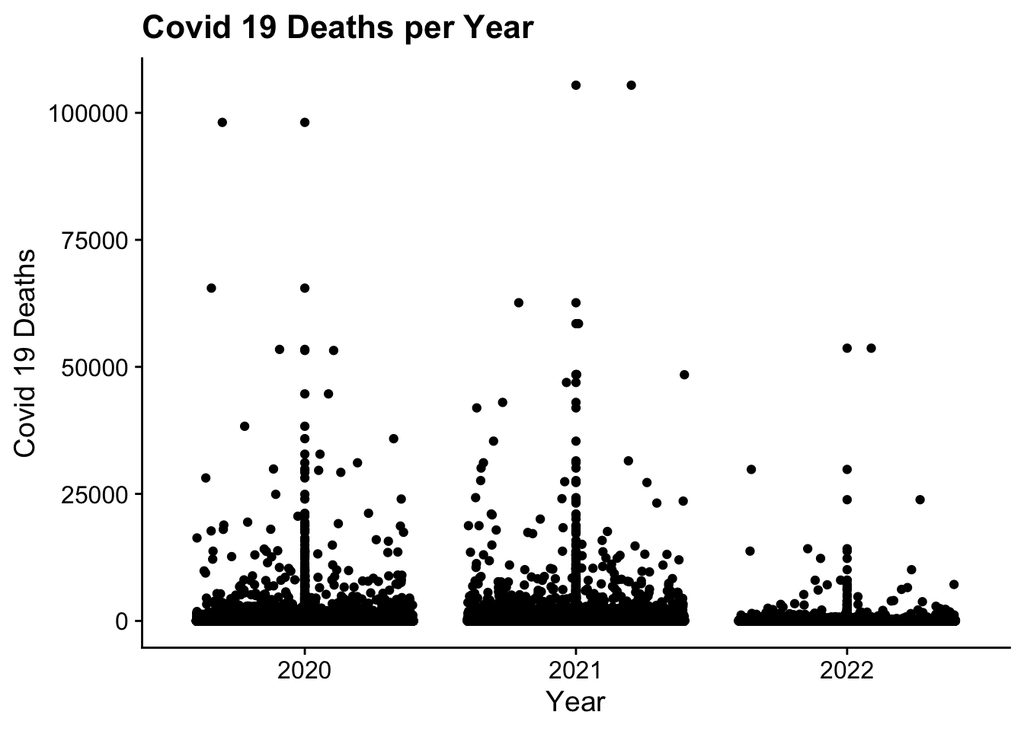

```r
CovidFilter <- filter(Covid_19, Group == "By Month")
CovidYear <- group_by(CovidFilter, Year, Month)

ggplot(CovidYear) +
  geom_jitter() +
  aes(x= factor(Year), y= COVID.19.Deaths) +
    ggtitle("Covid 19 Deaths per Year") +
  xlab("Year") +
  ylab("Covid 19 Deaths") +
  geom_point() +
  theme_cowplot()
```

Next, we can visualize if there is a difference in COVID-19 Deaths per month.

Additional modifications to the plotting outline are needed. One can use the dplyr function group_by to group desired data from different columns/variables in a dataframe. In addition, we want to run the Month X-variable as a factor, instead of a numerical variable. This distinction is made within the aes() function, and is necessary to obtain the appropriate x-axis values. If you are curious about this functions effect, change “aes(x= factor(Month), y= COVID.19.Deaths)” to “aes(x= Month, y=COVID.19.Deaths)” for graph p1 and note the difference.

[figure not shown]

```r
CovidFilterMonth1 <- filter(Covid_19, Group == "By Month", Year == "2020") #filter is used here to filter out all groups that are not organized by month. We also filtered by the Year so we will only see data for 2020.
CovidMonth1 <- group_by(CovidFilterMonth1, Year, Month) #group_by is used to group the data into Year and Month

# p# is used below to lable each graph to make it easier to visualize them together later.
p1 <- ggplot(CovidMonth1) +
  geom_jitter() +
  aes(x= factor(Month), y= COVID.19.Deaths) +
    ggtitle("Deaths per Month in 2020") +
  xlab("Month") +
  ylab("Covid 19 Deaths") +
  geom_point() +
  theme_cowplot()

CovidFilterMonth2 <- filter(Covid_19, Group == "By Month", Year == "2021")
CovidMonth2 <- group_by(CovidFilterMonth2, Year, Month)

p2 <- ggplot(CovidMonth2) +
  geom_jitter() +
  aes(x= factor(Month), y= COVID.19.Deaths) +
    ggtitle("Deaths per Month in 2021") +
  xlab("Month") +
  ylab("Covid 19 Deaths") +
  geom_point() +
  theme_cowplot()

CovidFilterMonth3 <- filter(Covid_19, Group == "By Month", Year == "2022")
CovidMonth3 <- group_by(CovidFilterMonth2, Year, Month)

p3 <- ggplot(CovidMonth3) +
  geom_jitter() +
  aes(x= factor(Month), y= COVID.19.Deaths) +
    ggtitle("Deaths per Month in 2022") +
  xlab("Month") +
  ylab("Covid 19 Deaths") +
  geom_point() +
  theme_cowplot()

plot_grid(p1,p2,p3,ncol=2) #plot_grid allows us to plot all of the graphs next to one another for easier comparison
```

2. Plots tp visualize if older individuals have higher death rates than younger individuals.